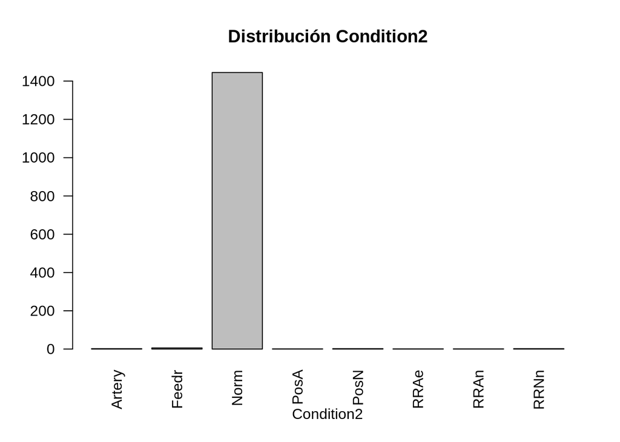

```r
barplot(table(dataSet$Condition2),main = "Distribución Condition2",
        xlab="Condition2",las=2)
```

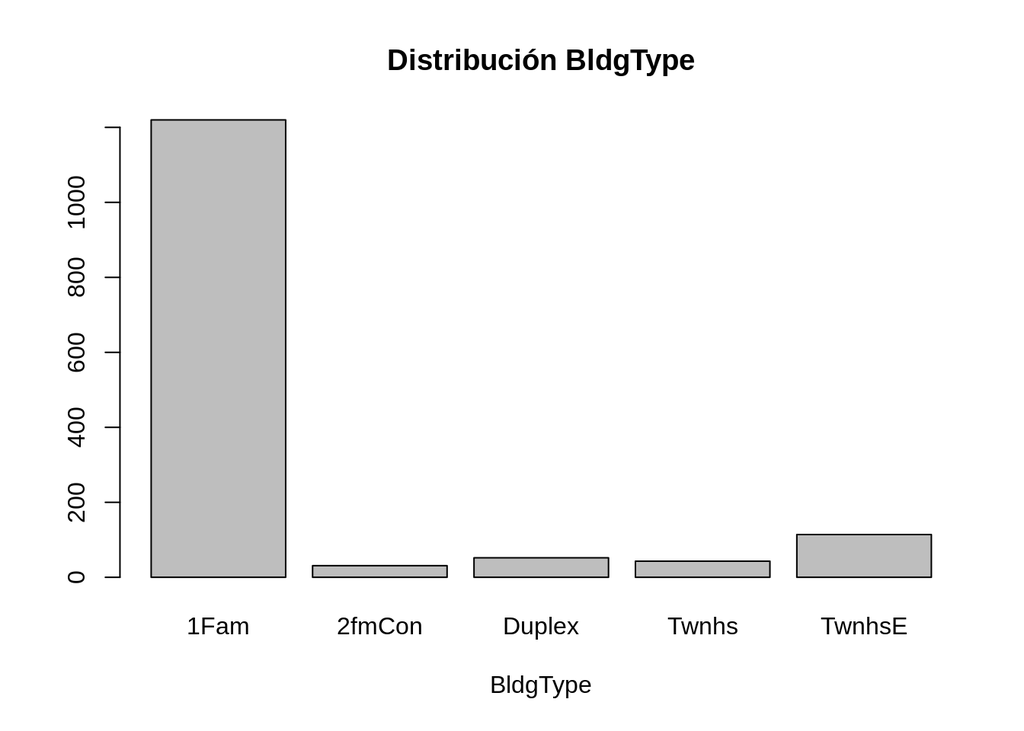

```r
barplot(table(dataSet$BldgType),main = "Distribución BldgType",
        xlab="BldgType")
```

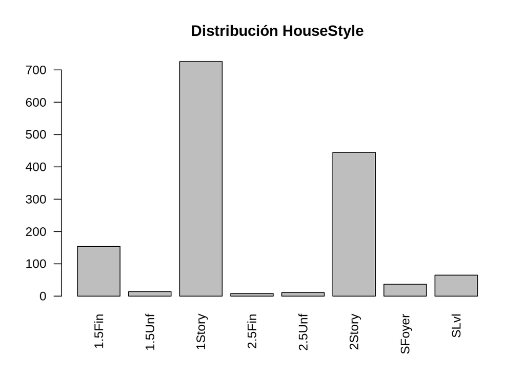

```r
barplot(table(dataSet$HouseStyle),main = "Distribución HouseStyle",
        las=2)
```

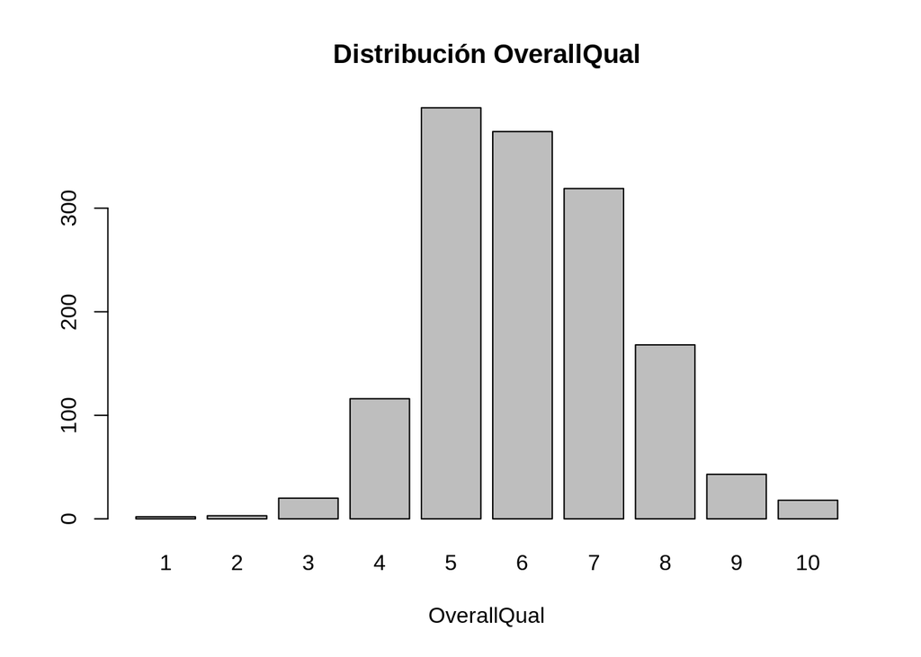

```r
barplot(table(dataSet$OverallQual),main = "Distribución OverallQual",
        xlab="OverallQual")
```

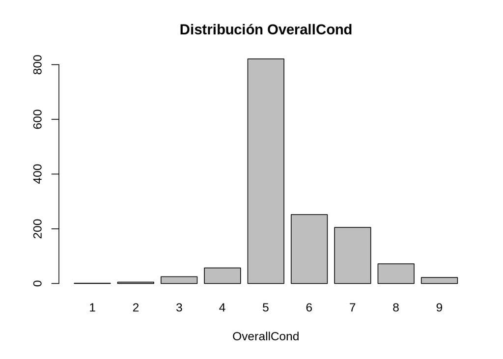

```r
barplot(table(dataSet$OverallCond),main = "Distribución OverallCond",
        xlab="OverallCond")
```

```r
knitr::kable(
  table(dataSet$YearBuilt), caption = 'Tabla de frecuencia YearBuilt'
)
```

Tabla de frecuencia YearBuilt

| Var1 | Freq |
| --- | --- |
| 1872 | 1 |
| 1875 | 1 |
| 1880 | 4 |
| 1882 | 1 |
| 1885 | 2 |
| 1890 | 2 |
| 1892 | 2 |
| 1893 | 1 |
| 1898 | 1 |
| 1900 | 10 |
| 1904 | 1 |
| 1905 | 1 |
| 1906 | 1 |
| 1908 | 2 |
| 1910 | 17 |
| 1911 | 1 |
| 1912 | 3 |
| 1913 | 1 |
| 1914 | 7 |
| 1915 | 10 |
| 1916 | 8 |
| 1917 | 1 |
| 1918 | 7 |
| 1919 | 3 |
| 1920 | 30 |
| 1921 | 6 |
| 1922 | 8 |
| 1923 | 7 |
| 1924 | 7 |
| 1925 | 16 |

[output cut: 82 more lines]

```r
knitr::kable(
  table(dataSet$YearRemodAdd), caption = 'Tabla de frecuencia YearRemodAdd'
)
```

Tabla de frecuencia YearRemodAdd

| Var1 | Freq |
| --- | --- |
| 1950 | 178 |
| 1951 | 4 |
| 1952 | 5 |
| 1953 | 10 |
| 1954 | 14 |
| 1955 | 9 |
| 1956 | 10 |
| 1957 | 9 |
| 1958 | 15 |
| 1959 | 18 |
| 1960 | 12 |
| 1961 | 8 |
| 1962 | 14 |
| 1963 | 13 |
| 1964 | 11 |
| 1965 | 19 |
| 1966 | 15 |
| 1967 | 12 |
| 1968 | 17 |
| 1969 | 14 |
| 1970 | 26 |
| 1971 | 18 |
| 1972 | 20 |
| 1973 | 11 |
| 1974 | 7 |
| 1975 | 10 |
| 1976 | 30 |
| 1977 | 25 |
| 1978 | 16 |
| 1979 | 10 |
| 1980 | 12 |
| 1981 | 8 |
| 1982 | 7 |
| 1983 | 5 |
| 1984 | 7 |
| 1985 | 9 |
| 1986 | 5 |
| 1987 | 10 |
| 1988 | 9 |
| 1989 | 11 |
| 1990 | 15 |
| 1991 | 14 |
| 1992 | 17 |
| 1993 | 19 |
| 1994 | 22 |
| 1995 | 31 |
| 1996 | 36 |
| 1997 | 25 |
| 1998 | 36 |
| 1999 | 30 |
| 2000 | 55 |
| 2001 | 21 |
| 2002 | 48 |
| 2003 | 51 |
| 2004 | 62 |
| 2005 | 73 |
| 2006 | 97 |
| 2007 | 76 |
| 2008 | 40 |
| 2009 | 23 |
| 2010 | 6 |

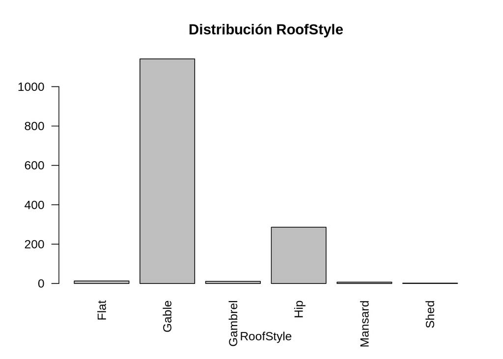

```r
barplot(table(dataSet$RoofStyle),main = "Distribución RoofStyle",
        xlab="RoofStyle",las=2)
```

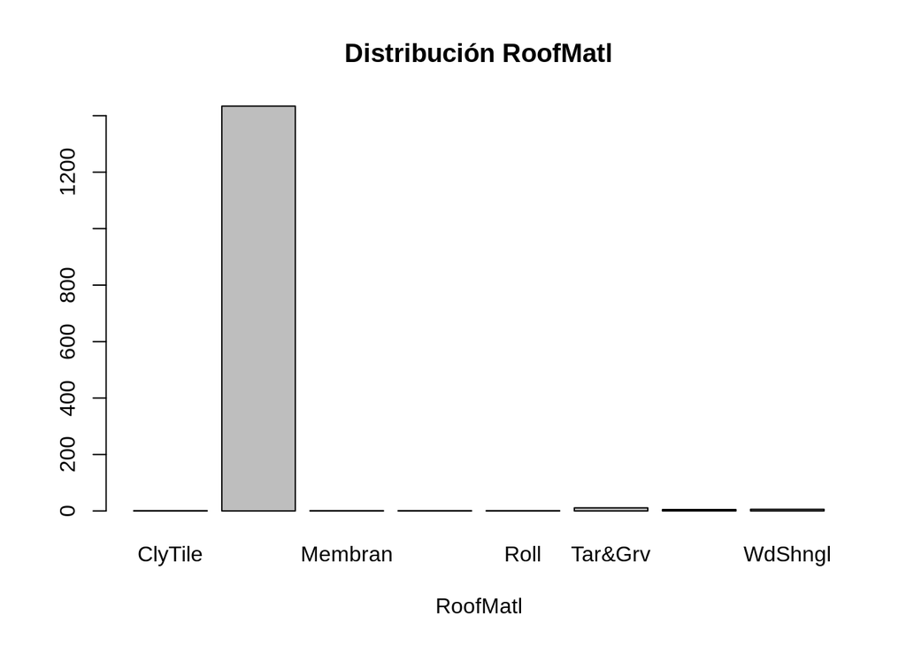

```r
barplot(table(dataSet$RoofMatl),main = "Distribución RoofMatl",
        xlab="RoofMatl")
```

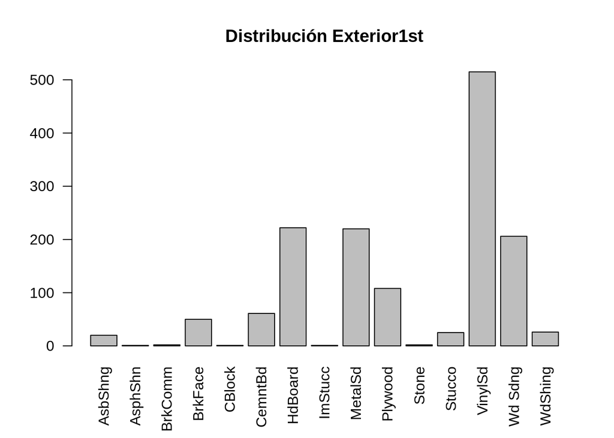

```r
barplot(table(dataSet$Exterior1st),main = "Distribución Exterior1st",
         las=2)
```

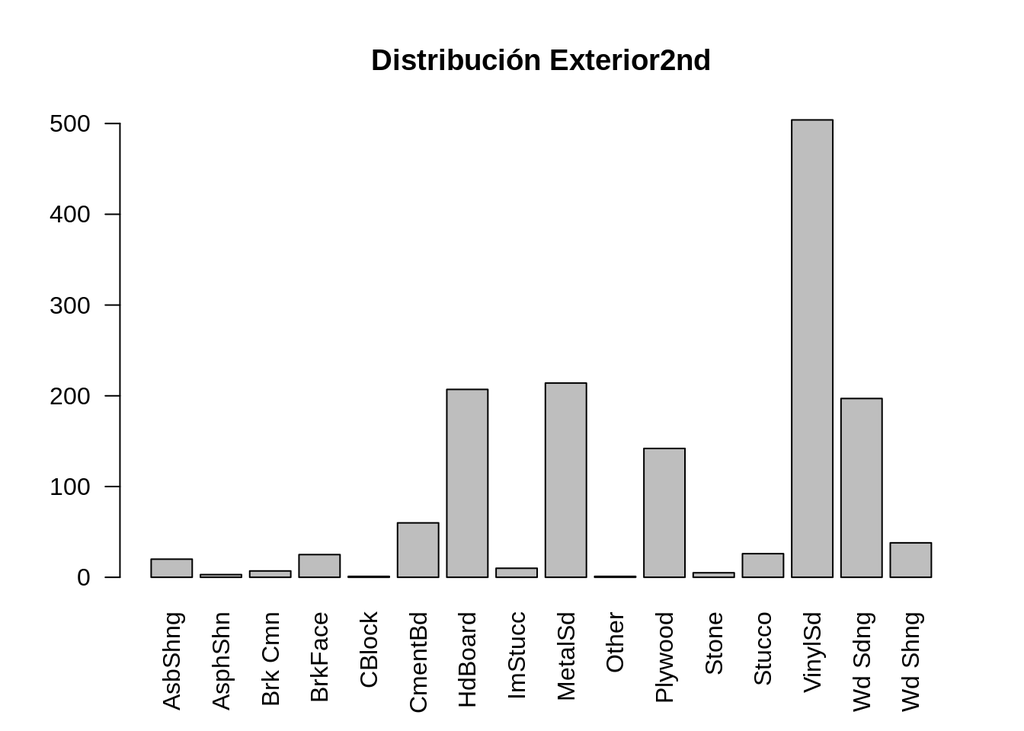

```r
barplot(table(dataSet$Exterior2nd),main = "Distribución Exterior2nd",
         las=2)
```

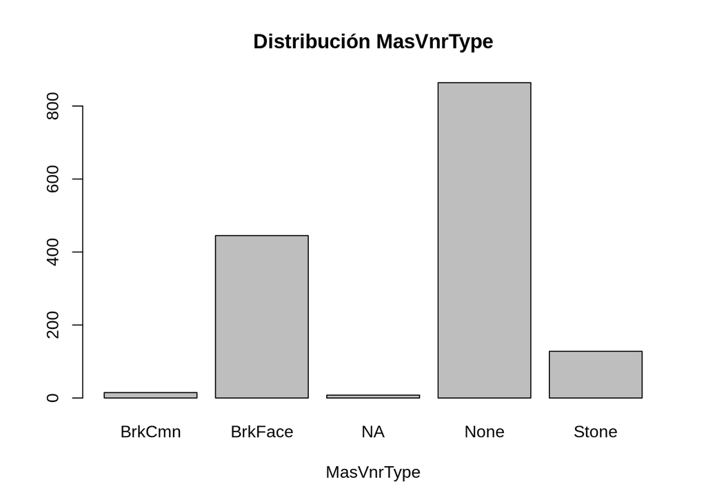

```r
barplot(table(dataSet$MasVnrType),main = "Distribución MasVnrType",
        xlab="MasVnrType")
```

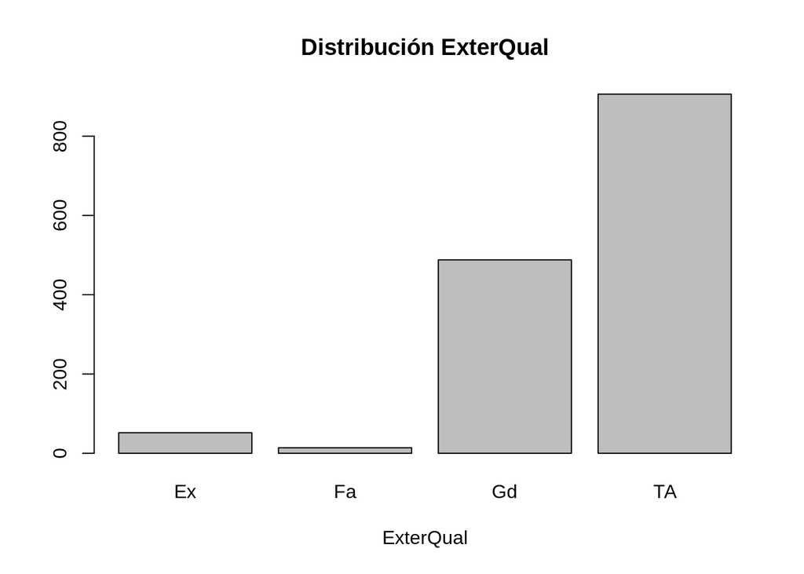

```r
barplot(table(dataSet$ExterQual),main = "Distribución ExterQual",
        xlab="ExterQual")
```

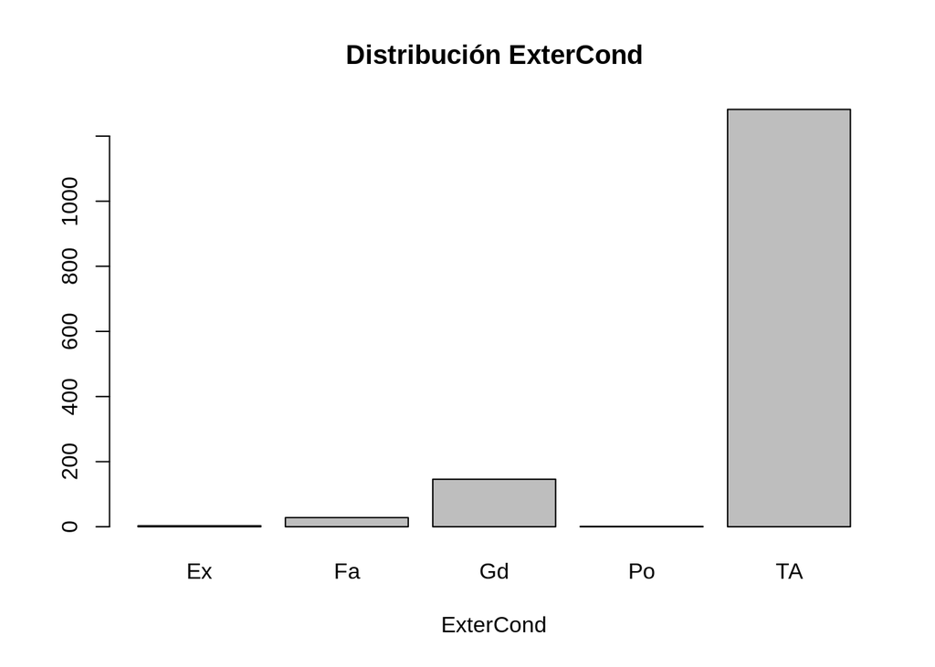

```r
barplot(table(dataSet$ExterCond),main = "Distribución ExterCond",
        xlab="ExterCond")
```

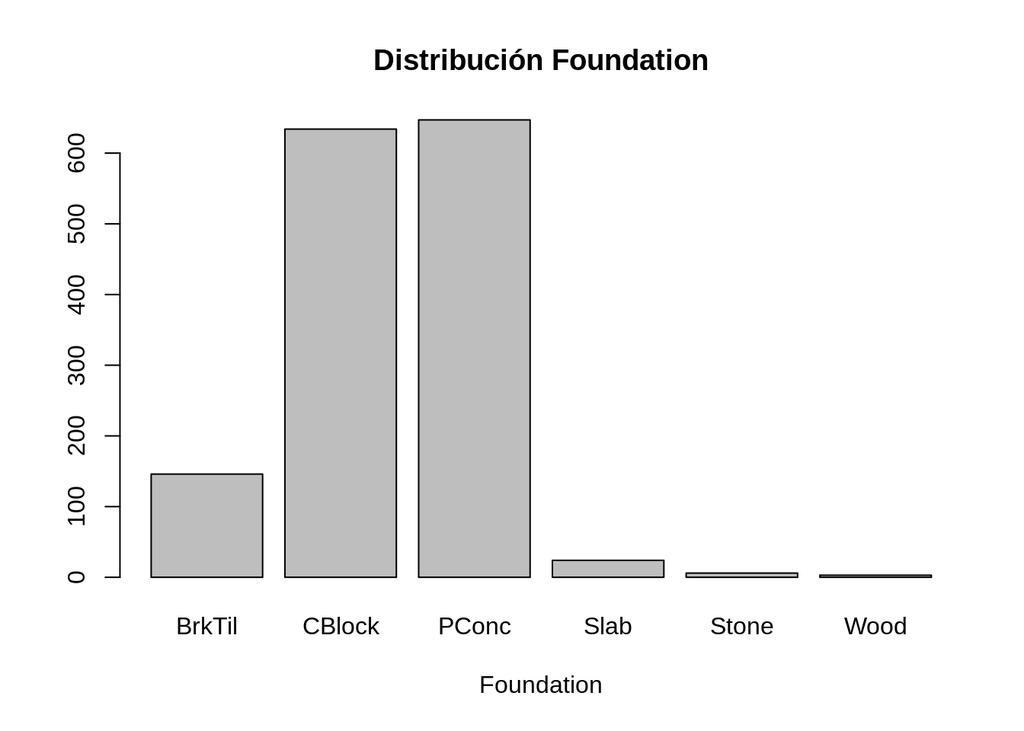

```r
barplot(table(dataSet$Foundation),main = "Distribución Foundation",
        xlab="Foundation")
```

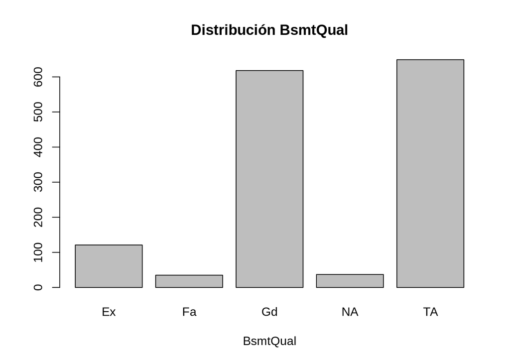

```r
barplot(table(dataSet$BsmtQual),main = "Distribución BsmtQual",
        xlab="BsmtQual")
```

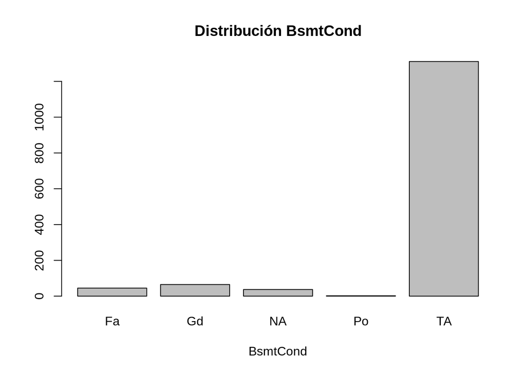

```r
barplot(table(dataSet$BsmtCond),main = "Distribución BsmtCond",
        xlab="BsmtCond")
```

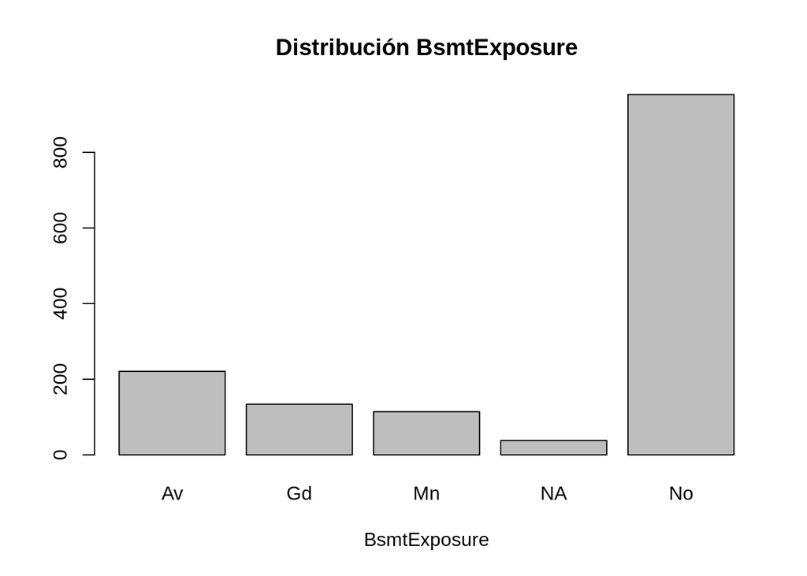

```r
barplot(table(dataSet$BsmtExposure),main = "Distribución BsmtExposure",
        xlab="BsmtExposure")
```

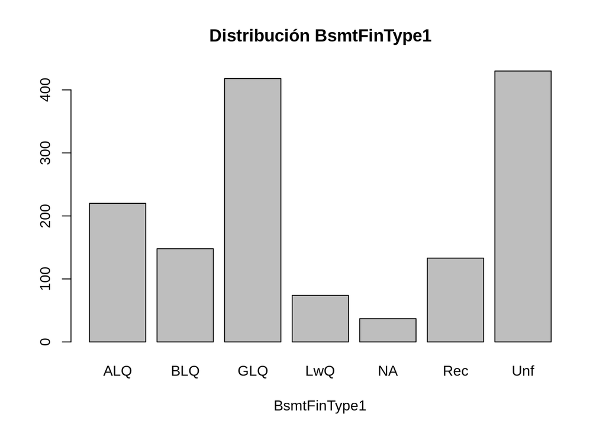

```r
barplot(table(dataSet$BsmtFinType1),main = "Distribución BsmtFinType1",
        xlab="BsmtFinType1")
```

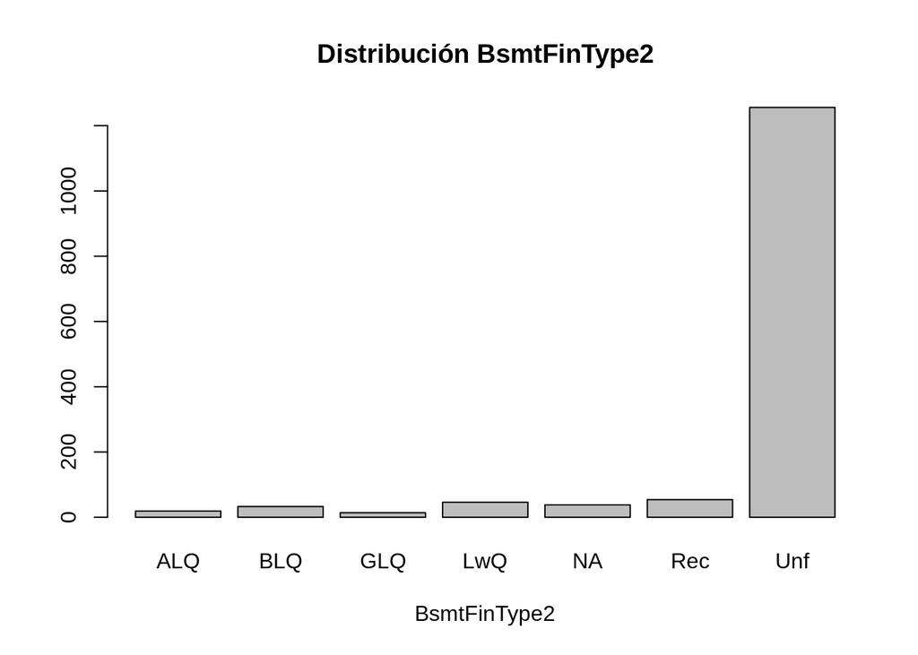

```r
barplot(table(dataSet$BsmtFinType2),main = "Distribución BsmtFinType2",
        xlab="BsmtFinType2")
```

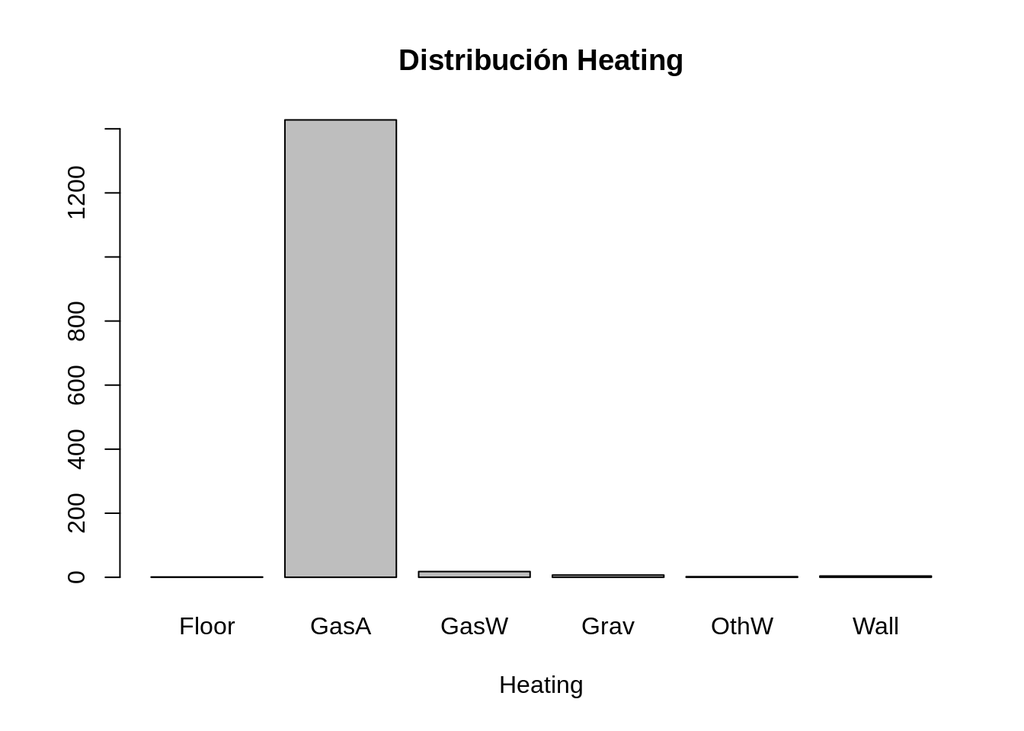

```r
barplot(table(dataSet$Heating),main = "Distribución Heating",
        xlab="Heating")
```

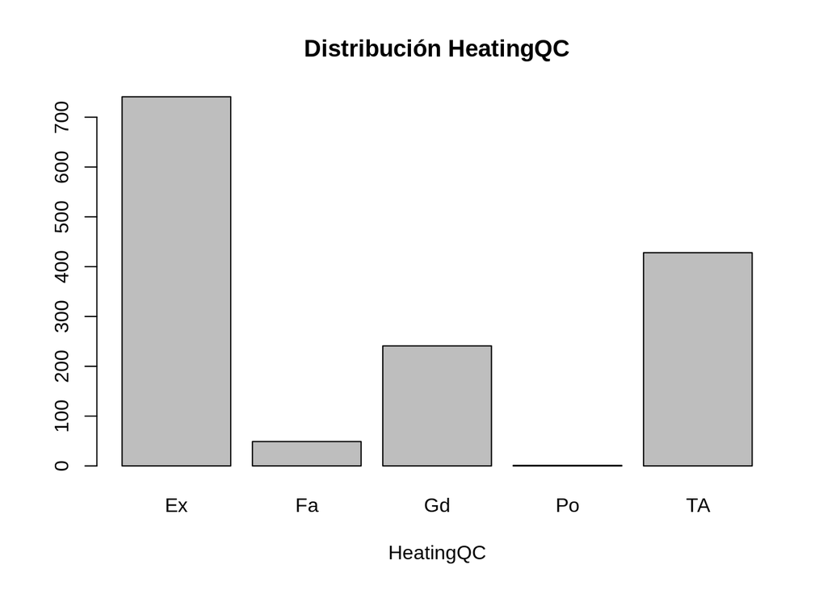

```r
barplot(table(dataSet$HeatingQC),main = "Distribución HeatingQC",
        xlab="HeatingQC")
```

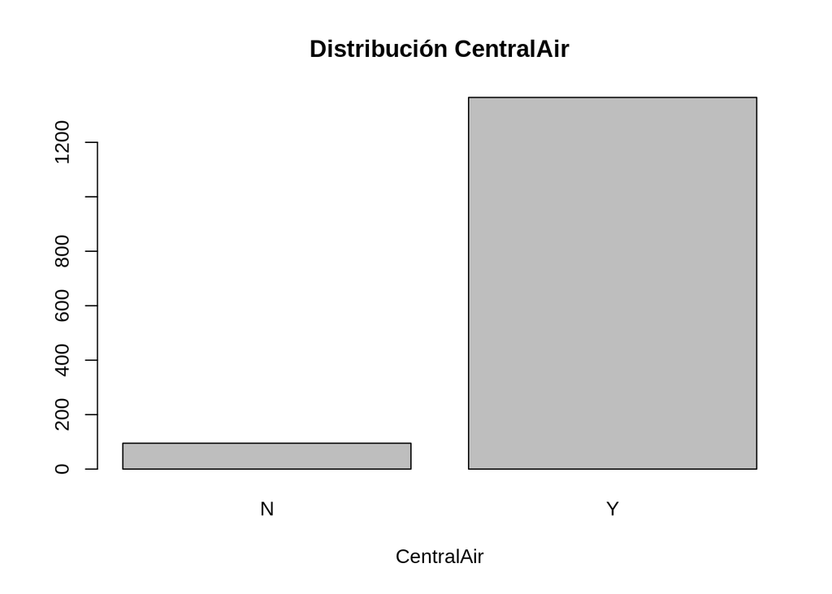

```r
barplot(table(dataSet$CentralAir),main = "Distribución CentralAir",
        xlab="CentralAir")
```

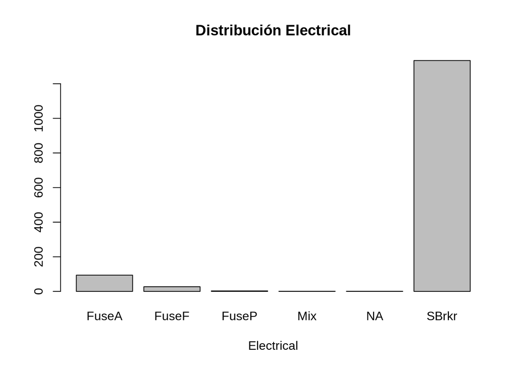

```r
barplot(table(dataSet$Electrical),main = "Distribución Electrical",
        xlab="Electrical")
```

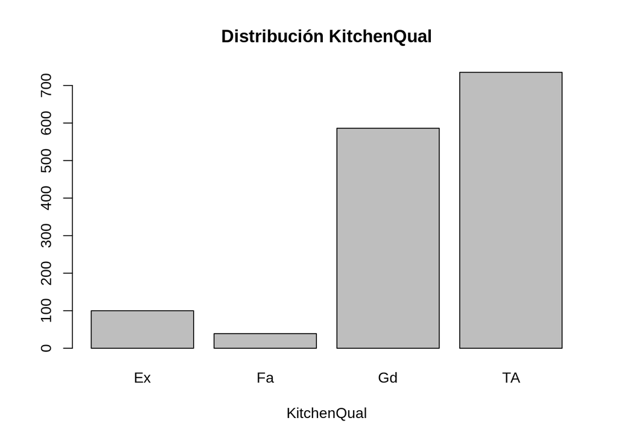

```r
barplot(table(dataSet$KitchenQual),main = "Distribución KitchenQual",
        xlab="KitchenQual")
```

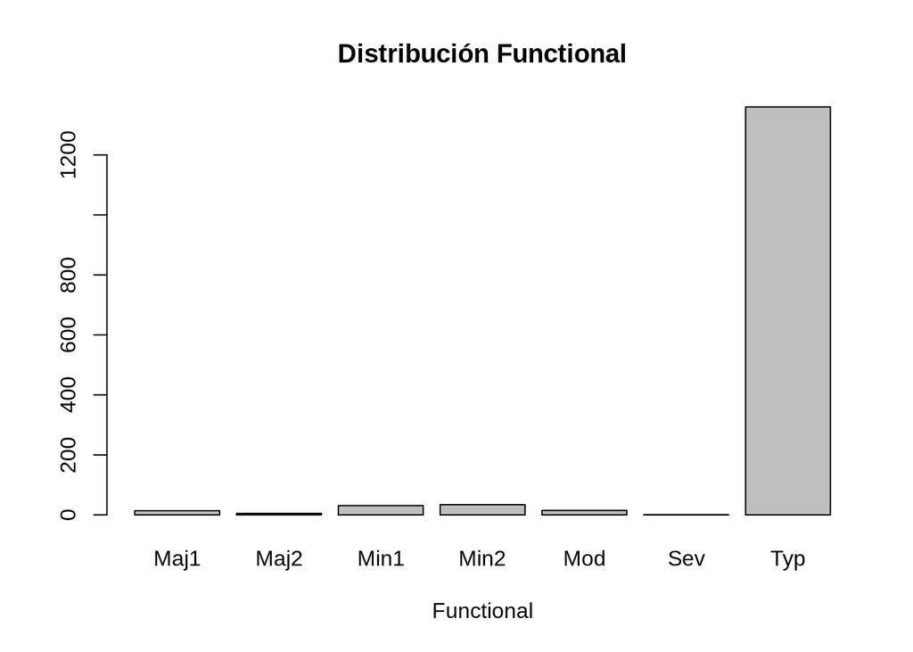

```r
barplot(table(dataSet$Functional),main = "Distribución Functional",
        xlab="Functional")
```

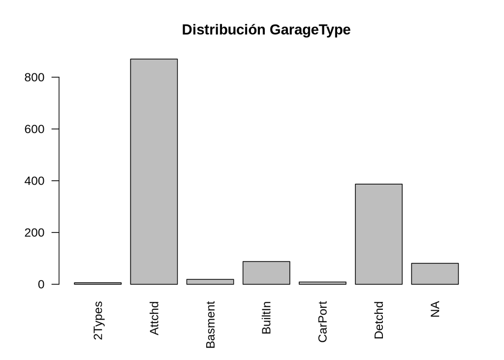

```r
barplot(table(dataSet$GarageType),main = "Distribución GarageType",
        las=2)
```

```r
knitr::kable(
  table(dataSet$GarageYrBlt), caption = 'Tabla de frecuencia GarageYrBlt'
)
```

Tabla de frecuencia GarageYrBlt

| Var1 | Freq |
| --- | --- |
| 1900 | 1 |
| 1906 | 1 |
| 1908 | 1 |
| 1910 | 3 |
| 1914 | 2 |
| 1915 | 2 |
| 1916 | 5 |
| 1918 | 2 |
| 1920 | 14 |
| 1921 | 3 |
| 1922 | 5 |
| 1923 | 3 |
| 1924 | 3 |
| 1925 | 10 |
| 1926 | 6 |
| 1927 | 1 |
| 1928 | 4 |
| 1929 | 2 |
| 1930 | 8 |
| 1931 | 4 |
| 1932 | 3 |
| 1933 | 1 |
| 1934 | 2 |
| 1935 | 4 |
| 1936 | 5 |
| 1937 | 2 |
| 1938 | 3 |
| 1939 | 9 |
| 1940 | 14 |
| 1941 | 10 |

[output cut: 68 more lines]

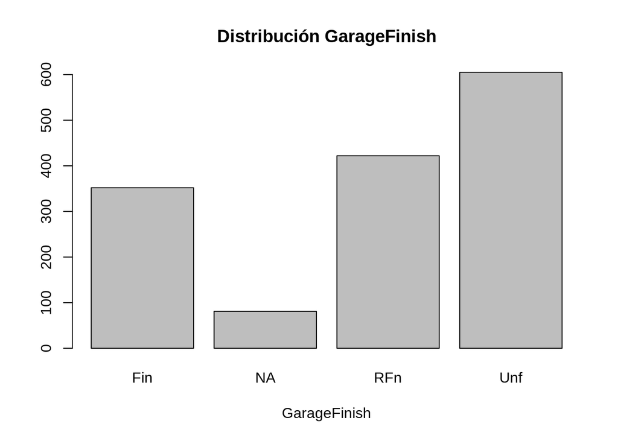

```r
barplot(table(dataSet$GarageFinish),main = "Distribución GarageFinish",
        xlab="GarageFinish")
```

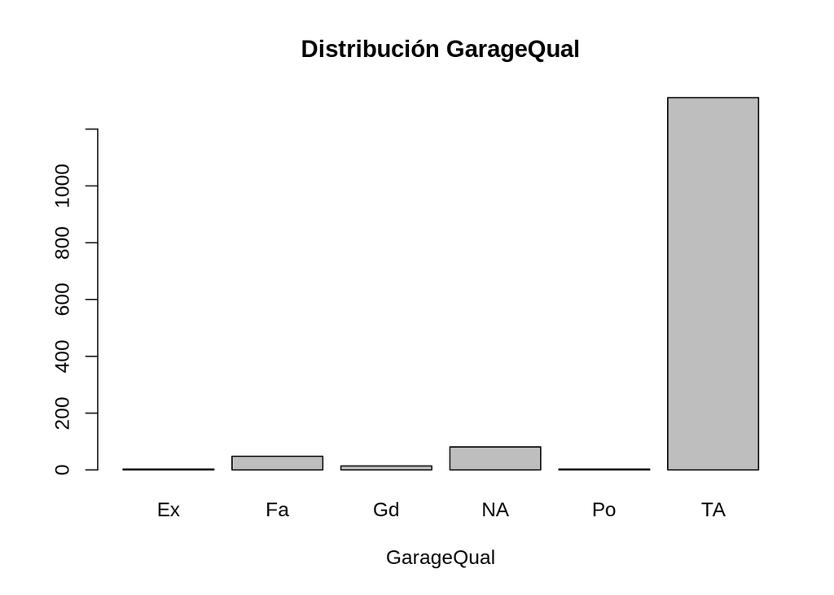

```r
barplot(table(dataSet$GarageQual),main = "Distribución GarageQual",
        xlab="GarageQual")
```

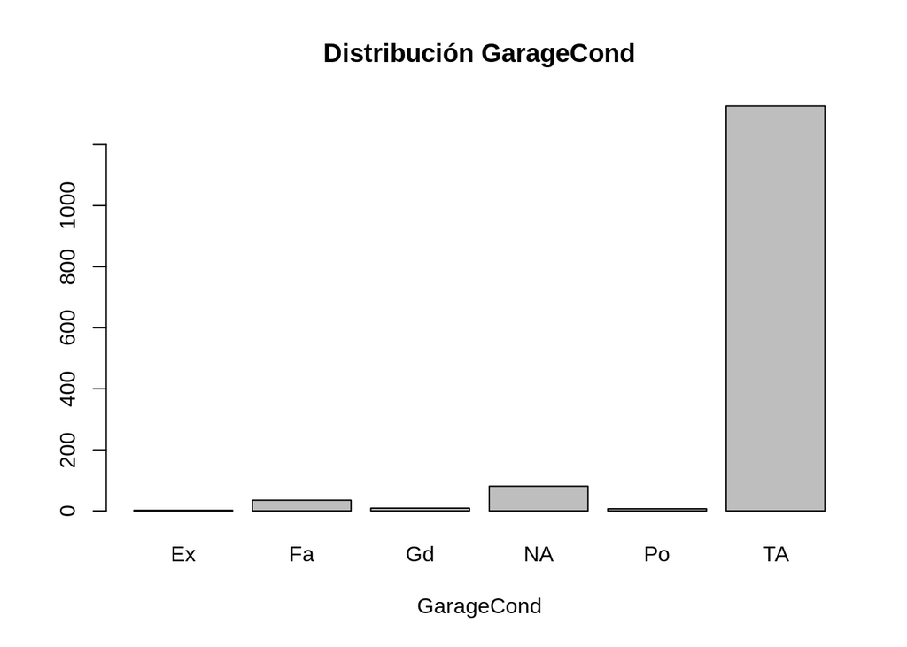

```r
barplot(table(dataSet$GarageCond),main = "Distribución GarageCond",
        xlab="GarageCond")
```

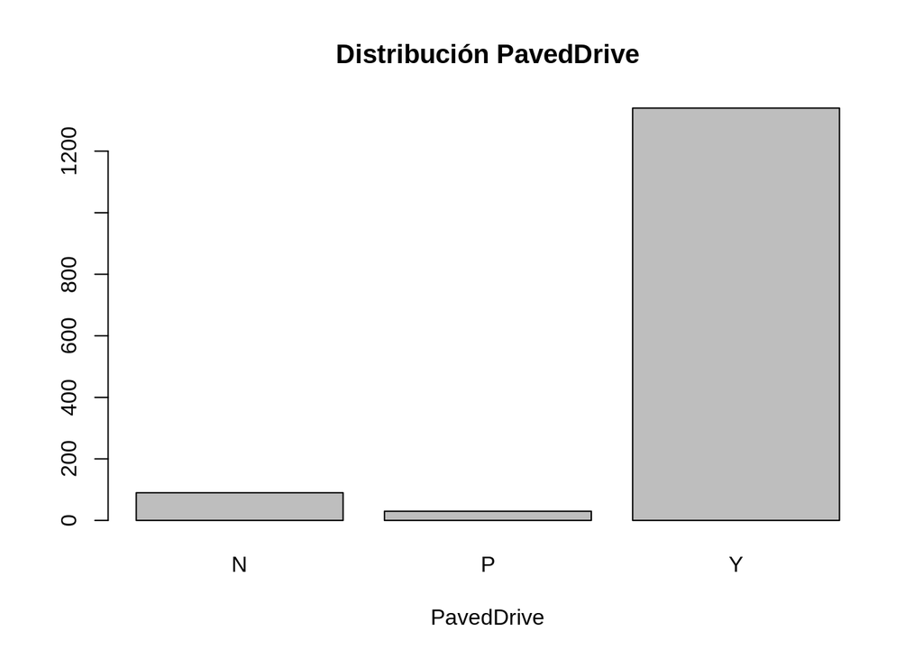

```r
barplot(table(dataSet$PavedDrive),main = "Distribución PavedDrive",
        xlab="PavedDrive")
```

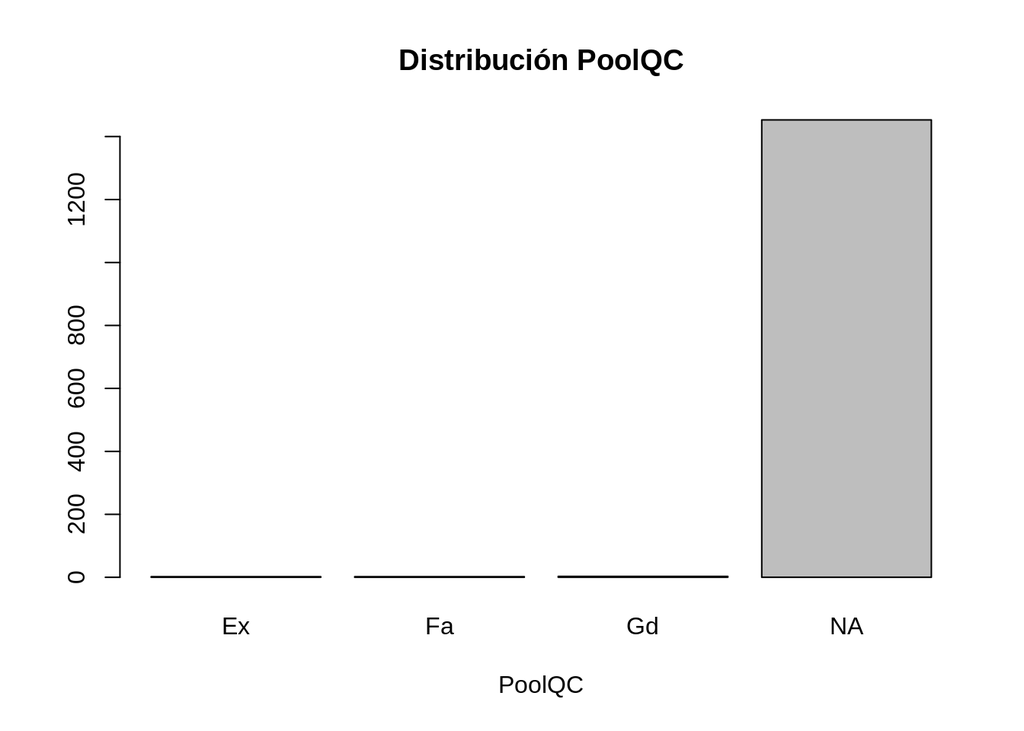

```r
barplot(table(dataSet$PoolQC),main = "Distribución PoolQC",
        xlab="PoolQC")
```

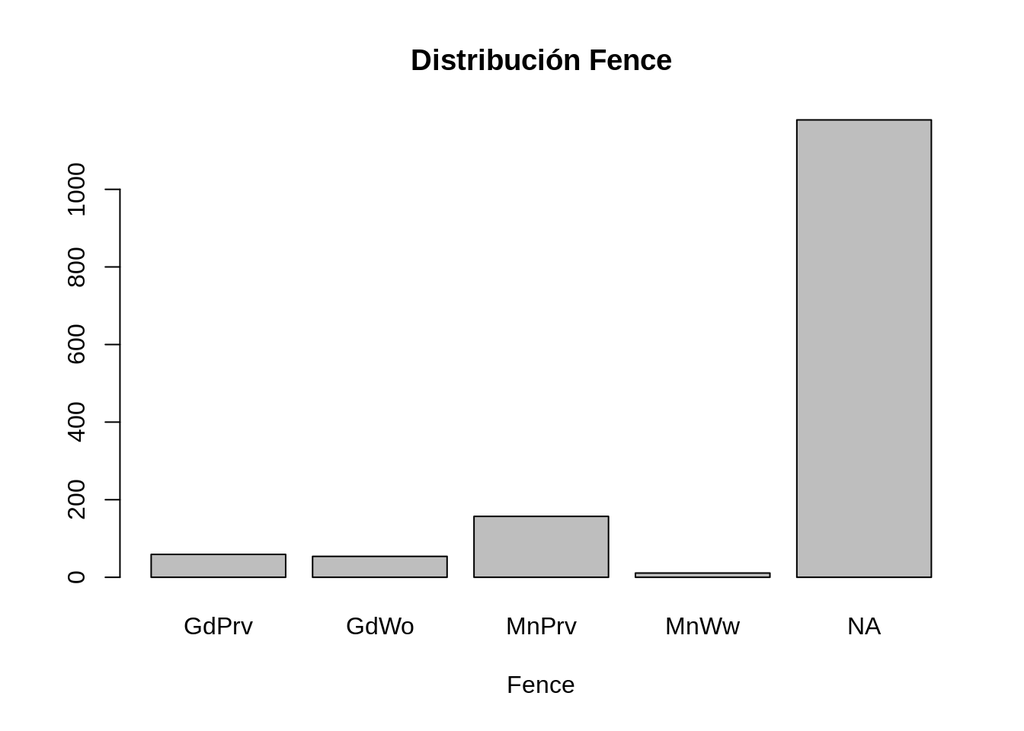

```r
barplot(table(dataSet$Fence),main = "Distribución Fence",
        xlab="Fence")
```

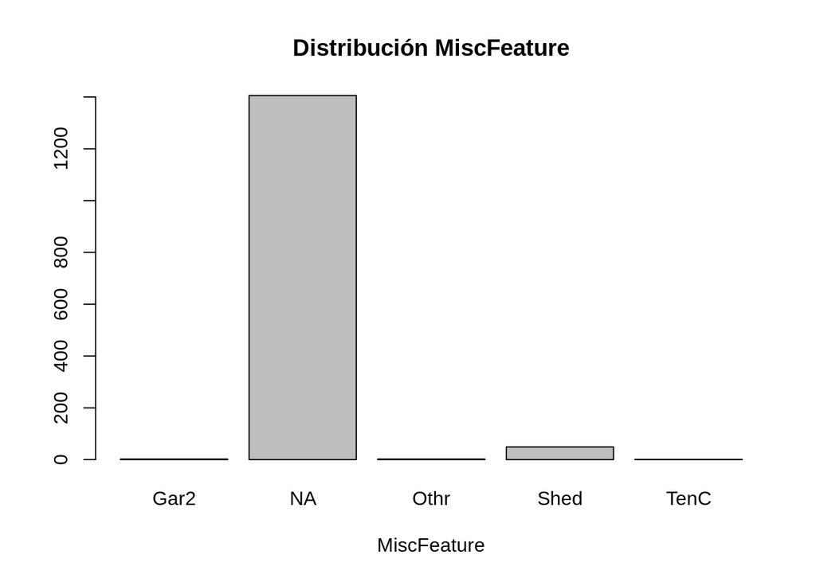

```r
barplot(table(dataSet$MiscFeature),main = "Distribución MiscFeature",
        xlab="MiscFeature")
```

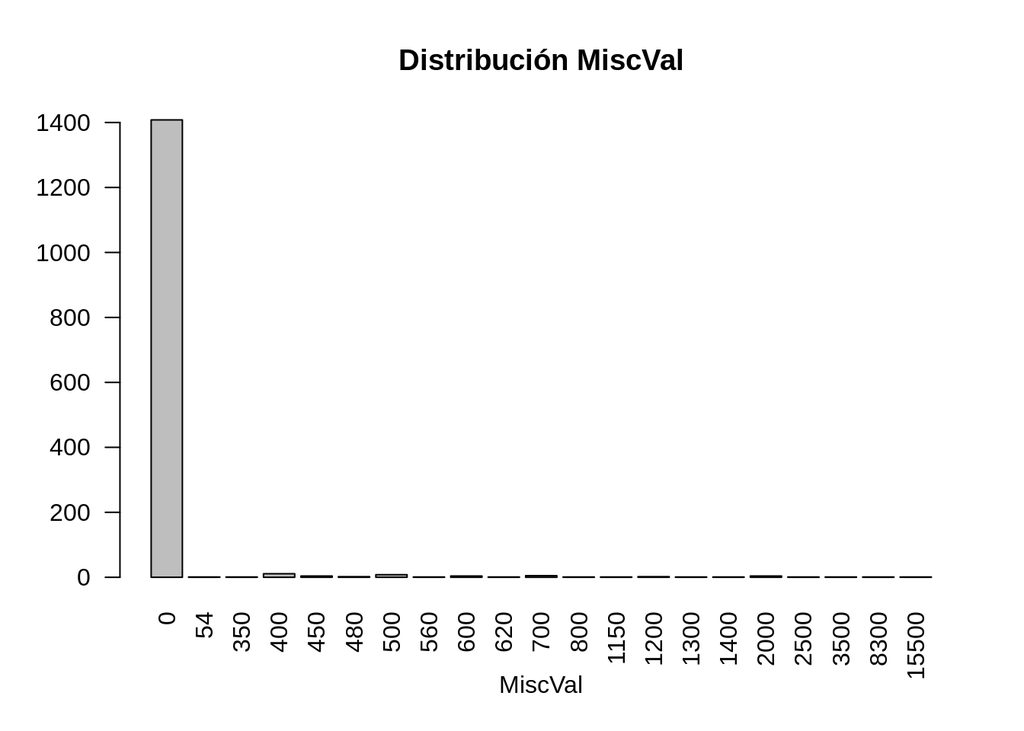

```r
barplot(table(dataSet$MiscVal),main = "Distribución MiscVal",
        xlab="MiscVal",las=2)
```

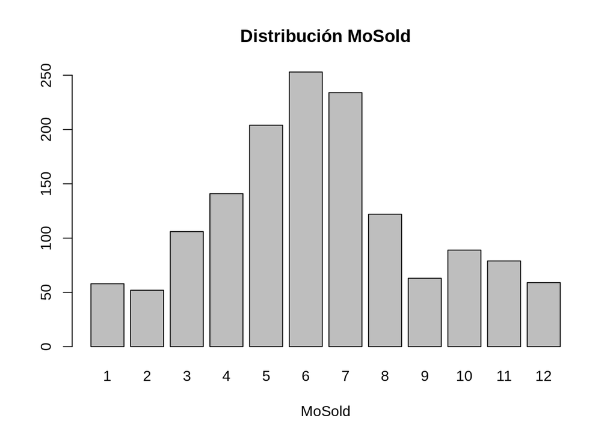

```r
barplot(table(dataSet$MoSold),main = "Distribución MoSold",
        xlab="MoSold")
```

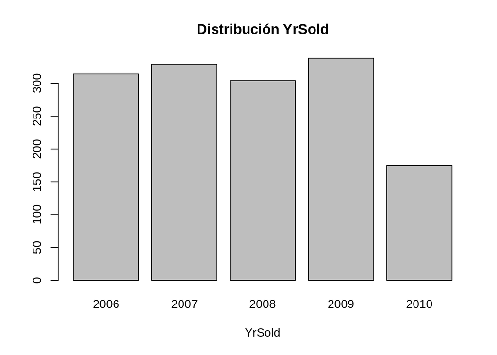

```r
barplot(table(dataSet$YrSold),main = "Distribución YrSold",
        xlab="YrSold")
```

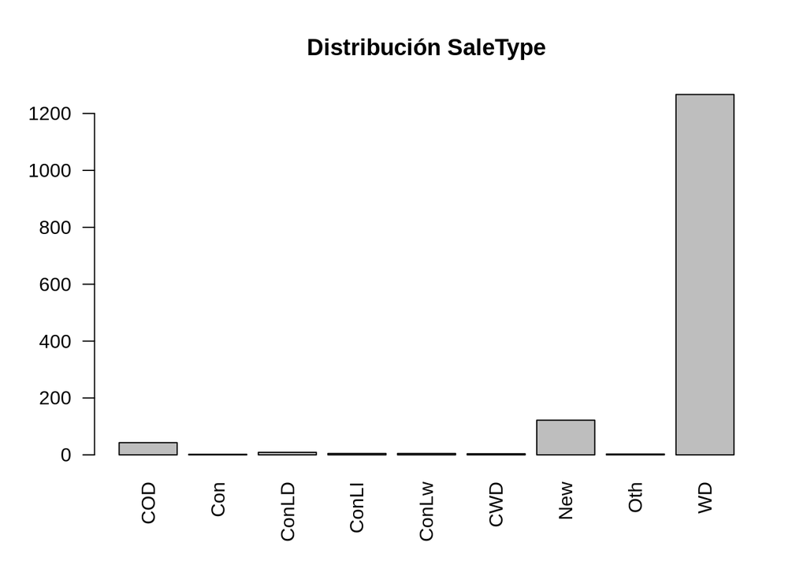

```r
barplot(table(dataSet$SaleType),main = "Distribución SaleType",
        las=2)
```

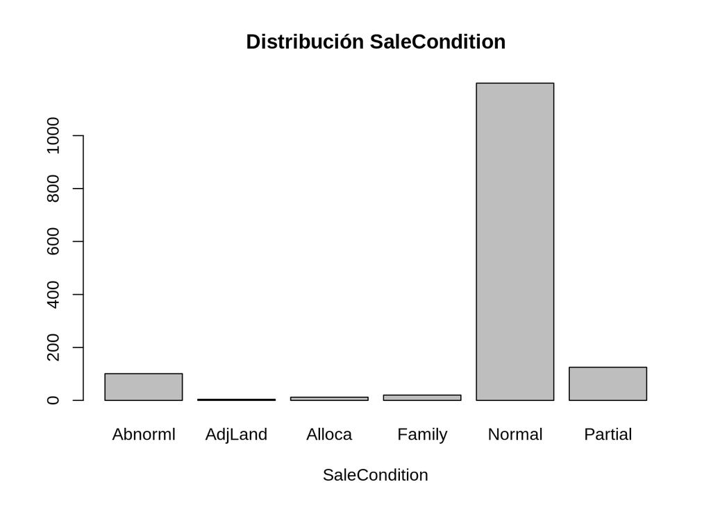

```r
barplot(table(dataSet$SaleCondition),main = "Distribución SaleCondition",
        xlab="SaleCondition")
```

Como podemos observar en la mayoría de las variables no hay valores NAs y si lo hay es mínima. Las únicas variables que tienen una fuerte presencia de estos son las siguientes: calidad de la piscina (PoolQC), calidad de la cerca (Fence), características extras (MiscFeature). Podemos suponer que estas variables tienen ausencia de valores debido a que son características que no todas las casas tienen.

## Preguntas para conocer mejor los datos

Preparación de los datos:

```r
rowNumbers <- c()
varNames <- c()

# Obtener vector de columnas num?ricas
for(name in colnames(dataSet)){
  if(is.numeric(dataSet[1,name]) && name != "Id")
  {
    rowNumbers <- c(rowNumbers, which(colnames(dataSet)==name))
    varNames <- c(varNames, name)
  }
}
```

```r
# ¿Cuál es la capacidad promedio en carros de los garajes de las casas más caras?
carrosCasasDesc <- dataSet[order(dataSet$SalePrice, decreasing = TRUE),c("GarageCars","SalePrice")]
mean(carrosCasasDesc[1:50,1])
```

```
## [1] 2.92
```

4. ¿Cuál es el promedio de cuartos que tienen las 200 casas más caras?

```r
mean(head(dataSet[order(dataSet$SalePrice,decreasing = TRUE),c("BedroomAbvGr")], n = 200))
```

```
## [1] 3.02
```

El promedio de cuartos que tienen las 200 casas más caras es de 3 cuartos.

5. ¿En qué intervalo de años han sido construidas las casas más caras?

```r
table(head(dataSet[order(dataSet$SalePrice,decreasing = TRUE),c("YearBuilt")], n = 200))
```

```
##
## 1880 1892 1893 1932 1934 1935 1939 1941 1945 1958 1959 1965 1966 1968 1970 1971
##    2    1    1    1    1    1    1    1    1    1    2    1    1    1    1    1
## 1972 1974 1975 1976 1977 1979 1980 1981 1983 1985 1986 1988 1989 1990 1991 1992
##    1    1    1    2    1    1    1    2    1    1    1    1    2    4    1    3
## 1993 1994 1995 1996 1997 1998 1999 2000 2001 2002 2003 2004 2005 2006 2007 2008
##    4    7    7    6    1    7    4    2    6    4   11   13   18   24   20   17
## 2009 2010
##    6    1
```

Nuevamente tomamos como las casas más caras a las 200 casas con mayor precio de venta. Como podemos observar el año que se construyeron más casas caras fue wn el 2006. Le sigue el año 2007 y luego el año 2005.